# MA5761 Homework #3

Karthik Garimella

For homework assignments in this course, you will be provided with a knitted R notebook and the .rmd file used to create it. You are *encouraged* (but not required) to use the .rmd file as a template for your solutions.

## Kumaraswamy Distribution

The beta distribution is commonly used, but one drawback is that it does not have a nice closed-form expression for its cdf, making sampling from it somewhat difficult.

Alternatively, the *Kumaraswamay distribution* is a probability distribution with the pdf
$$f(x)=\alpha\beta
x^{\alpha-1}(1-x^\alpha)^{\beta-1},\quad 0<x<1$$
where $\alpha>0$ and $\beta>0$ are two *shape parameters*.

It it can be shown that the cdf of this distribution is
$$F(x)=1-(1-x^\alpha)^\beta,\quad
0<x<1$$

Write functions `dkumara`, `pkumara`, `qkumara`, and `rkumara` which implement the four standard R functions for a family of probability distributions (pdf, cdf, quantile function, and random sample generation). Create a sample of $n=10^4$ observations from this distribution with $\alpha=1.5$ and $\beta=4.5$, generate a density histogram of this sample, and overlay the theoretical pdf on top of it.

Calling the required ggplot library

```r
# Kumaraswamy Distribution

library(ggplot2)
```

##### The PDF function for the Kumaraswamy Distribution

```r
dkumara <- function(x, alpha = 1, beta = 0){
  #PDF of Kumaraswamy Distribution


  fx <- ifelse(x > 1 | x < 0 | x == 0, -Inf, alpha * beta * (x^(alpha - 1)) * (1 - x^alpha)^(beta - 1))

  return (fx)
}
```

##### The CDF function for the Kumaraswamy Distribution

```r
pkumara <- function(x, alpha, beta){
  #CDF of Kumaraswamy Distribution

  Fx <- ifelse(x > 1 | x < 0, 'x not in [0,1] range', 1 - (1 - x^alpha)^beta)

  return(Fx)
}
```

##### The Quantile function for the Kumaraswamy Distribution

```r
qkumara <- function(p, alpha, beta){
  #Quantile function of Kumaraswamy Distribution

  Qx <- (1 - (1 - p)^(1/beta))^(1/alpha)

  return(Qx)
}
```

##### Sampling with the Kumaraswamy Distribution

```r
rkumara <- function(n, alpha, beta){
  # Generating random sample for Kumaraswamy Distribution

  Rx <- qkumara(runif(n), alpha, beta)

  return(Rx)
}
```

##### Histogram of the Kumaraswamy Distribution and the theoretical PDF curve on top of it

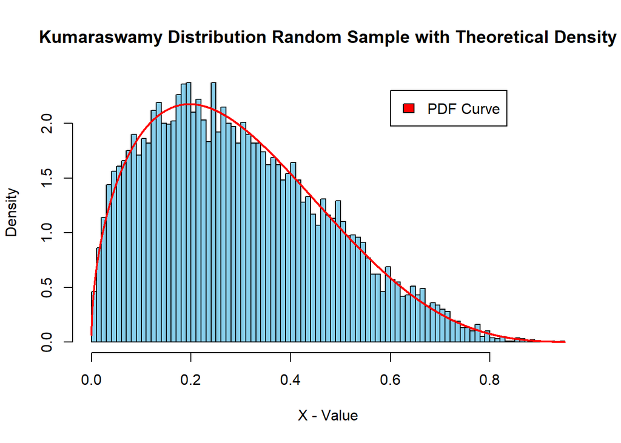

```r
#Density Histogram  and PDF curve overlayed

hist(rkumara(10^4, alpha = 1.5, beta = 4.5), breaks = 100, prob=TRUE, col = "skyblue", main = "Kumaraswamy Distribution Random Sample with Theoretical Density", xlab = "X - Value")

curve(dkumara(x, alpha = 1.5, beta = 4.5), add= TRUE, n = 10^4, col = "red", lwd = 2)

legend(0.6, 2.3, legend=c("PDF Curve"), fill = c("red"))
```

## Beta Distribution

Consider the problem of sampling from the $\mathsf{Beta}(1.5,4.5)$ distribution, using rejection sampling with the Kumaraswamy distribution as a proposal distribution.

Create a function, `f`, which is the pdf of this target distribution. Experiment with different values of $\alpha$ and $\beta$ in the proposal (Kumaraswamy) distribution to try and find a decent “match” to the target density. Create curves of both the target density and the proposal density on the same axes, and also a plot of the ratio $f(x)/g(x)$.

You need not chronicle all attempts made, but find a set of parameters $\alpha$ and $\beta$ for the proposal distribution which ensures $M=\max_{x\in(0,1)}f(x)/g(x)\le 1.1$. : Let $\beta=4.5$, and search for values of $\alpha$ that are near 1.5.

Once you have settled on a proposal distribution, estimate $M$ with the `optimize` function, and then plot $f(x)$ and $M\cdot g(x)$ on the same axes to visually verify you have an envelope to the target density.

Finally, generate a sample of size $10^4$ from the target distribution using rejection sampling. Report the percentage of points that were accepted, and verify that this is “close” to the theoretical acceptance probability of $1/M$. Create a density histogram of your sample, and overlay the theoretical target (beta) density on top of it.

##### Function f for the Beta Distribution

```r
#Beta Distribution sampling using Kumaraswamy Distribution

#We know kumara dist => g(x) (Proposal Dist) and now
#we need to sample beta dist => f(x) (Target Dist)

f <- function(x, alpha = 1, beta = 0){
  #PDF for Beta Distribution
  beta_func <- dbeta(x, alpha, beta)

  return(beta_func)
}
```

##### Matching the Kumaraswamy Curve with the Beta Curve

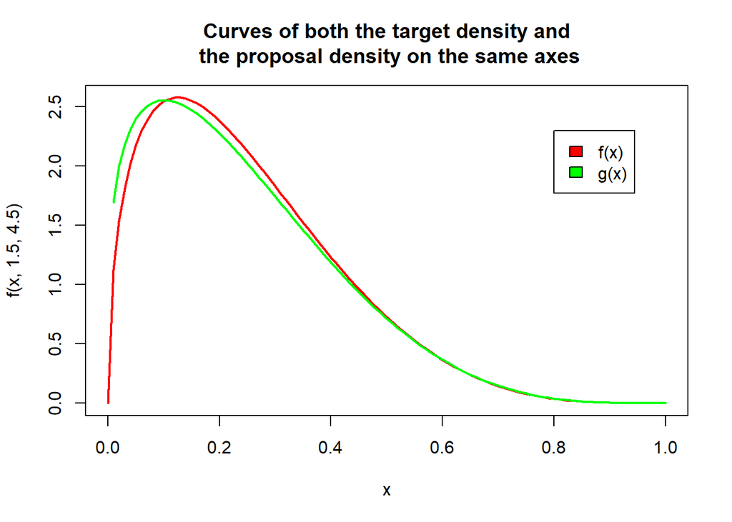

```r
#Curves of both the target density and the proposal density on the same axes
curve(f(x, 1.5, 4.5), col = 'red', lwd = 2)

curve(dkumara(x, 1.26, 4.5), add = T,col = 'green', lwd = 2)

title(main = 'Curves of both the target density and\n the proposal density on the same axes')

legend(0.8, 2.3, legend=c("f(x)","g(x)"), fill = c("red", "green"))
```

##### f(x)/g(x) ratio plot

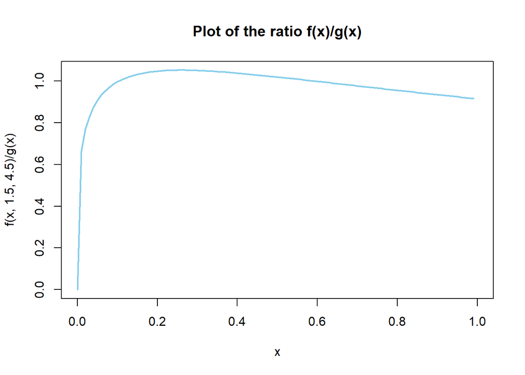

```r
#plot of the ratio f(x)/g(x)
g <- function(x) { dkumara(x, 1.26, 4.5) }

curve(f(x, 1.5, 4.5)/g(x), col = 'skyblue', lwd = 2)

title(main = 'Plot of the ratio f(x)/g(x)')
```

##### Finding the M value

```r
ratio <- function(x) {  (f(x, 1.5, 4.5)/ dkumara(x, 1.26, 4.5)) }

ratio
```

```
## function(x) {  (f(x, 1.5, 4.5)/ dkumara(x, 1.26, 4.5)) }
```

```r
result <- optimize(ratio, interval = c(0, 1), maximum = T)

result
```

```
## $maximum
## [1] 0.258517
##
## $objective
## [1] 1.05163
```

```r
M <- result$objective

M
```

```
## [1] 1.05163
```

##### Plotting f(x) and M * g(x) on the same plot to verify if there is an envelope to the target density.

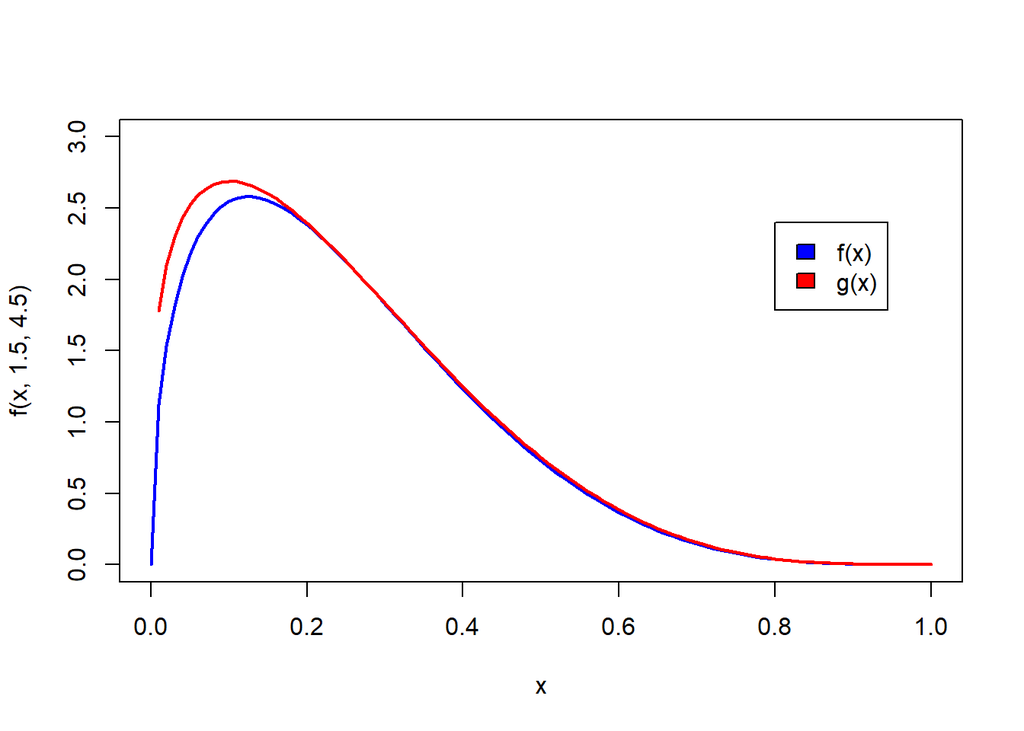

```r
curve(f(x, 1.5, 4.5), 0, 1, col = 'blue', lwd = 2, ylim = c(0,3))

curve( M * g(x), 0, 1, add = TRUE, col = 'red', lwd = 2)


legend(0.8, 2.4, legend=c("f(x)","g(x)"), fill = c("blue", "red"))
```

##### Setting up values to quantify the Accept and Reject Matching the Kumaraswamy Curve with the Beta Curve

```r
N <- 10^4
x <- rkumara(N, 1.26, 4.5)
u <- runif(N)
M <- 1.099927

status <- ifelse(u < f(x,1.5,4.5)/ (M *g(x)), 'Accept', 'Reject')

df <- data.frame(x = x, u = u, Status = factor(status))
```

##### Plotting the Accept/Reject ratio and curve using ggplot

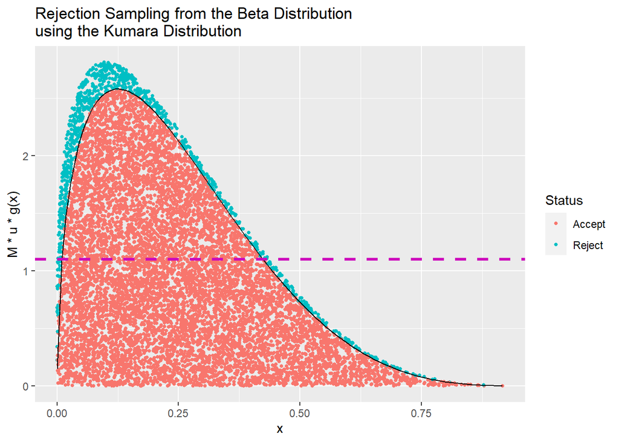

```r
ggplot(df, aes(x = x, y = M * u * g(x))) +
  geom_point(aes(col = Status), size = 1) +
  geom_function(data = NULL, fun = function(x) f(x, 1.5, 4.5), col = 'black', lwd = .5) +
  geom_hline(yintercept = M, lty = 'dashed', col = 6, lwd = 1.1) +
  ggtitle('Rejection Sampling from the Beta Distribution\nusing the Kumara Distribution')
```

##### Percentage of points that were accepted, and verifying if this is “close” to the theoretical acceptance probability of 1/M

```r
table(df$Status)
```

```
##
## Accept Reject
##   9080    920
```

```r
prop.table(table(df$Status))
```

```
##
## Accept Reject
##  0.908  0.092
```

```r
1/M
```

```
## [1] 0.9091512
```

##### And as we see, it is extremely close to the accepted probability of 1/M

##### Plotting density histogram of the sample and theoretical target beta density

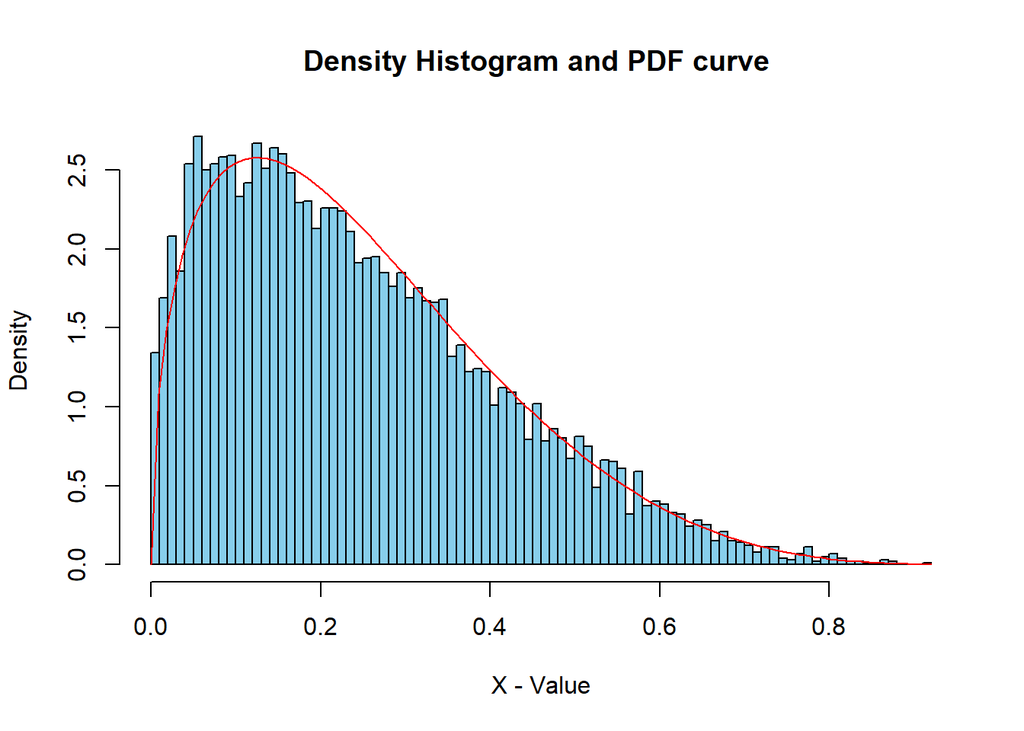

```r
#as.data.frame(df$x)

hist(df$x, breaks = 100, prob = T, col = 'skyblue', main = "Density Histogram and PDF curve ", xlab = "X - Value")

curve(f(x, 1.5, 4.5), add = T, col = 'red')
```

## Epanechnikov Distribution

The rescaled Epanechnikov kernel is a symmetric density function
$$f_e(x)=\tfrac34(1-x^2),\quad \lvert
x\rvert\le 1$$
Devroye and Gyorfi give the following algorithm for simulation from this distribution:

1. Generate iid $U_1,U_2,U_3\sim\mathsf{Uniform}(-1,1)$.
2. If $|U_3|\ge|U_2|$ and $|U_3|\ge|U_1|$, deliver $U_2$; otherwise deliver $U_3$.

Write a function which implements the density function of this distribution, and another function which generates random variates from $f_e$. Construct a density histogram of a large sample generated from this distribution, and overlay the theortical density on top of it.

##### PDF of Epanechnikov Distribution

```r
#Epanechnikov Distribution

depan <- function(x){
  #Density function for Epanechnikov Distribution

  fex <- ifelse( abs(x) > 1, 'NA', 3/4 * (1-(x^2)) )

  return(fex)
}
```

##### Generating samples of Epanechnikov Distribution

```r
repan <- function(n){
  #Generating random variates for Epanechnikov Distribution

  U1 <- runif(n, min = -1, max = 1)
  U2 <- runif(n, min = -1, max = 1)
  U3 <- runif(n, min = -1, max = 1)

  rex <- ifelse(abs(U3) >= abs(U2) & abs(U3) >= abs(U1), U2, U3)

  return(rex)
}
```

##### Density Histogram and PDF curve of Epanechnikov Distribution

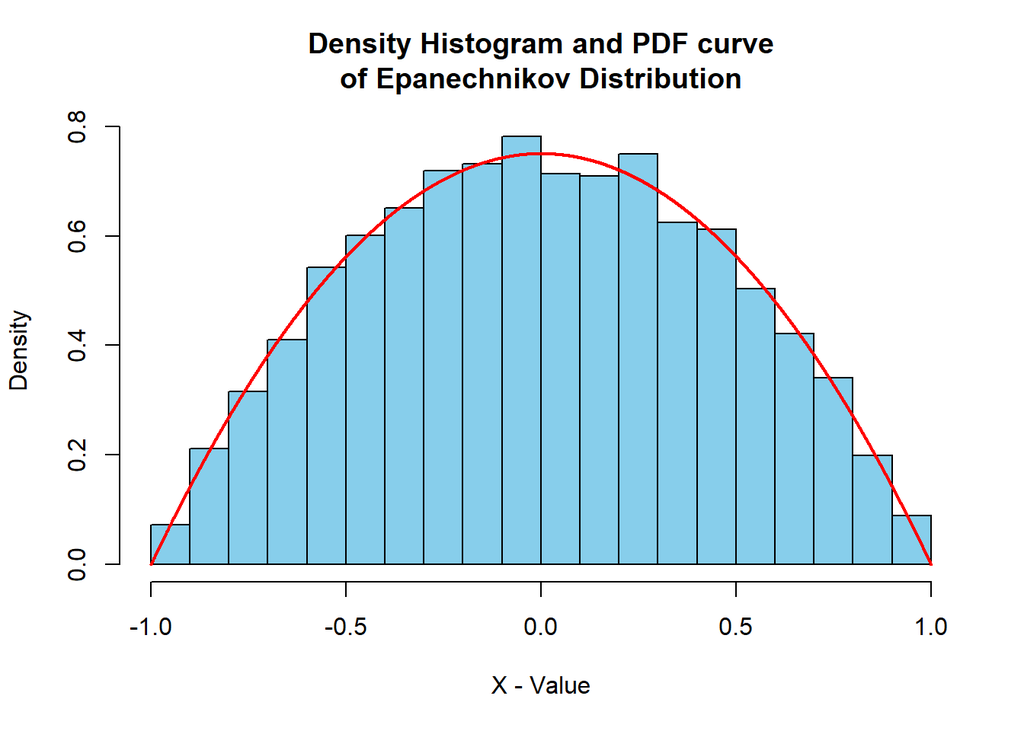

```r
#Density Histrogram and PDF layover

hist(repan(10^4), prob = T, col = 'skyblue', main = "Density Histogram and PDF curve\n of Epanechnikov Distribution ", xlab = "X - Value")

curve(depan(x), -1, 1, add = T, n = 10^4, col = 'red', lwd = 2)
```

## Normal Distribution

Create a function `my_rnorm` which generates a random sample of size $n$ from a normal distribution. This function should implement the Box-Muller transformation described in the notes, and then perform a scale and location transformation.

Check your work by generating a sample with your function (you pick $\mu$ and $\sigma$) and overlaying the theortical density (implemented with `dnorm`) on top of it.

##### Box-Muller transformation to generate random sample from a normal distribution

```r
#Normal Distribution


#The Box-Muller algorithm is used to make pairs of independent standard normal random variables via a transformation: Generate U1 and U2 as independent random variables uniformly distributed over the unit interval. Let X1=√−2log(U1) * cos(2πU2) and X2=√−2log(U1) * sin(2πU2). Then X1 and X2 are independent stanard normal random variables.



my_rnorm <- function(n, scale = 0, location = 1){
#Box-Muller transformation for generating random sample of size n from a normal distribution

  U1 <- runif(n, min = 0, max = 1)
  U2 <- runif(n, min = 0, max = 1)

  X1 <- sqrt(-2 * log(U1)) * cos(2 * pi * U2)
  X2 <- sqrt(-2 * log(U1)) * sin(2 * pi * U2)

  df <- scale + location * c(X1, X2)

  return(df)

}
```

##### Density plot and PDF curve for Box-Muller transformation

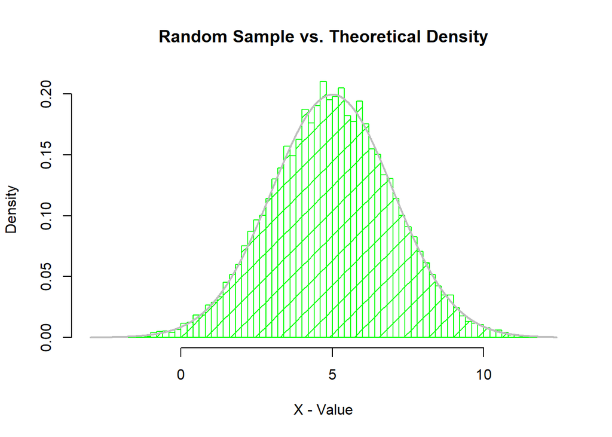

```r
#Density Histogram and PDF layover of Box-Muller transformation with dnorm curve with scale = 3 and location = 5

hist(my_rnorm(10^4, 5, 2), col = 'green', density = 5, prob = T, breaks = 100, main = "Random Sample vs. Theoretical Density", xlab = "X - Value")

curve(dnorm(x, 5, 2), add = T, n = 10^4, col = 'grey', lwd = 2)
```

## Student’s *t* (Non-central) Distribution

Recall that Student’s *t* distribution is defined as the probability distribution of
$$\frac{Z+\delta}{\sqrt{W/\nu}}$$
where $Z$ has a standard normal distribution and $W$ has a $\chi^2$ distribution with $\nu$ degrees of freedom. Here, $\delta$ is called a *non-centrality parameter*. When $\delta=0$, the distribution is simply called “Student’s *t*”; if $\delta\ne0$, the distribution is said to be non-central.

Write a function `my_rt` which generates a sample from Student’s *t* distribution using the above definition. This function should have the arguments `n` (the sample size), `df` (the degrees of freedom), and `ncp` (the non-centrality parameter, with a default value of 0). Your function should call functions like `my_rnorm` and `my_rchisq` which also implement random sample generation from the normal distribution and $\chi^2$ distribution.

Use your function to generate a sample of size $10^4$ from the non-central *t* distribution with 20 degrees of freedom and a non-centrality parameter of -2. Create a density histogram of your sample, and overlay the theoretical density (implemented from R’s `dt` function) on top of this.

##### Random Samples of Normal Distribution

```r
#Student’s t (Non-central) Distribution

my_rnorm <- function(n){
  #Normal Distribution Sample Generation

  return(rnorm(n))
}
```

##### Random Samples of Chi Square distribution

```r
my_rchisq <- function(n, df) {
  #Chi Square Distribution Sample Generation

  z <- rowSums(matrix(rnorm(n*df), nrow = n)^2)

  return(z)
}
```

##### Random Samples of Student’s t (Non-central) Distribution

```r
my_rt <- function(n, df, ncp = 0){
  #Student’s t distribution Sample Generation

  Z = my_rnorm(n)
  W = my_rchisq(n, df)

  StD = (Z + ncp)/(sqrt(W/df))

  return(StD)

}
```

##### Plotting Student’s t (Non-central) Distribution with 10^4 sample size, 20 degrees of freedom and non-centrality parameter of -2

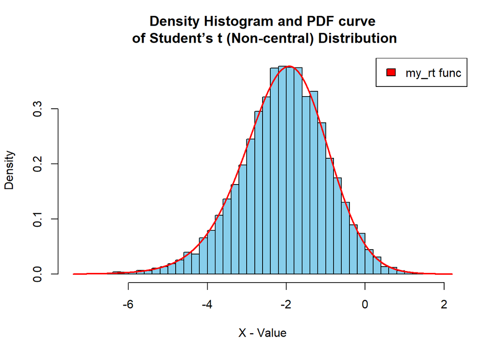

```r
hist(my_rt(10^4, 20, -2), prob = T, breaks = 50, col = 'skyblue', main = "Density Histogram and PDF curve\n of Student’s t (Non-central) Distribution", xlab = "X - Value")

curve(dt(x, 20, -2), add = T, n = 10^4, col = 'red', lwd = 2)

legend(x = "topright", legend=c("my_rt func"), fill = c("red"))
```